# Risk Factor Analysis

## Outcome Variable

**Outcome Variable:** stunted

## Predictor Variables

**Intervention Variable:** enstunt

**Adjustment Set:**

- arm
- sex
- W_mage
- meducyrs
- feducyrs
- hhwealth_quart
- vagbrth
- W_nrooms
- brthmon
- W_parity
- impfloor
- impsan
- safeh20
- delta_W_mage
- delta_meducyrs
- delta_feducyrs
- delta_hhwealth_quart
- delta_vagbrth
- delta_W_nrooms
- delta_brthmon
- delta_W_parity
- delta_impfloor
- delta_impsan
- delta_safeh20

## Stratifying Variables

The analysis was stratified on these variable(s):

- agecat
- studyid
- country

## Data Summary

| agecat | studyid | country | enstunt | stunted | n_cell | n |
| --- | --- | --- | --- | --- | --- | --- |
| Birth | ki0047075b-MAL-ED | BANGLADESH | 0 | 0 | 210 | 257 |
| Birth | ki0047075b-MAL-ED | BANGLADESH | 0 | 1 | 0 | 257 |
| Birth | ki0047075b-MAL-ED | BANGLADESH | 1 | 0 | 0 | 257 |
| Birth | ki0047075b-MAL-ED | BANGLADESH | 1 | 1 | 47 | 257 |
| Birth | ki0047075b-MAL-ED | BRAZIL | 0 | 0 | 170 | 191 |
| Birth | ki0047075b-MAL-ED | BRAZIL | 0 | 1 | 0 | 191 |
| Birth | ki0047075b-MAL-ED | BRAZIL | 1 | 0 | 0 | 191 |
| Birth | ki0047075b-MAL-ED | BRAZIL | 1 | 1 | 21 | 191 |
| Birth | ki0047075b-MAL-ED | INDIA | 0 | 0 | 173 | 206 |
| Birth | ki0047075b-MAL-ED | INDIA | 0 | 1 | 0 | 206 |
| Birth | ki0047075b-MAL-ED | INDIA | 1 | 0 | 0 | 206 |
| Birth | ki0047075b-MAL-ED | INDIA | 1 | 1 | 33 | 206 |
| Birth | ki0047075b-MAL-ED | NEPAL | 0 | 0 | 155 | 173 |
| Birth | ki0047075b-MAL-ED | NEPAL | 0 | 1 | 0 | 173 |
| Birth | ki0047075b-MAL-ED | NEPAL | 1 | 0 | 0 | 173 |
| Birth | ki0047075b-MAL-ED | NEPAL | 1 | 1 | 18 | 173 |
| Birth | ki0047075b-MAL-ED | PERU | 0 | 0 | 253 | 287 |
| Birth | ki0047075b-MAL-ED | PERU | 0 | 1 | 0 | 287 |
| Birth | ki0047075b-MAL-ED | PERU | 1 | 0 | 0 | 287 |
| Birth | ki0047075b-MAL-ED | PERU | 1 | 1 | 34 | 287 |
| Birth | ki0047075b-MAL-ED | SOUTH AFRICA | 0 | 0 | 234 | 262 |
| Birth | ki0047075b-MAL-ED | SOUTH AFRICA | 0 | 1 | 0 | 262 |
| Birth | ki0047075b-MAL-ED | SOUTH AFRICA | 1 | 0 | 0 | 262 |
| Birth | ki0047075b-MAL-ED | SOUTH AFRICA | 1 | 1 | 28 | 262 |
| Birth | ki0047075b-MAL-ED | TANZANIA, UNITED REPUBLIC OF | 0 | 0 | 105 | 123 |
| Birth | ki0047075b-MAL-ED | TANZANIA, UNITED REPUBLIC OF | 0 | 1 | 0 | 123 |
| Birth | ki0047075b-MAL-ED | TANZANIA, UNITED REPUBLIC OF | 1 | 0 | 0 | 123 |
| Birth | ki0047075b-MAL-ED | TANZANIA, UNITED REPUBLIC OF | 1 | 1 | 18 | 123 |
| Birth | ki1000108-CMC-V-BCS-2002 | INDIA | 0 | 0 | 74 | 90 |
| Birth | ki1000108-CMC-V-BCS-2002 | INDIA | 0 | 1 | 0 | 90 |

[output cut: 314 more lines]

The following strata were considered:

- agecat: 24 months, studyid: ki0047075b-MAL-ED, country: BANGLADESH
- agecat: 24 months, studyid: ki0047075b-MAL-ED, country: BRAZIL
- agecat: 24 months, studyid: ki0047075b-MAL-ED, country: INDIA
- agecat: 24 months, studyid: ki0047075b-MAL-ED, country: NEPAL
- agecat: 24 months, studyid: ki0047075b-MAL-ED, country: PERU
- agecat: 24 months, studyid: ki0047075b-MAL-ED, country: SOUTH AFRICA
- agecat: 24 months, studyid: ki0047075b-MAL-ED, country: TANZANIA, UNITED REPUBLIC OF
- agecat: 24 months, studyid: ki1000108-CMC-V-BCS-2002, country: INDIA
- agecat: 24 months, studyid: ki1000108-IRC, country: INDIA
- agecat: 24 months, studyid: ki1017093-NIH-Birth, country: BANGLADESH
- agecat: 24 months, studyid: ki1017093b-PROVIDE, country: BANGLADESH
- agecat: 24 months, studyid: ki1017093c-NIH-Crypto, country: BANGLADESH
- agecat: 24 months, studyid: ki1066203-TanzaniaChild2, country: TANZANIA, UNITED REPUBLIC OF
- agecat: 24 months, studyid: ki1101329-Keneba, country: GAMBIA
- agecat: 24 months, studyid: ki1113344-GMS-Nepal, country: NEPAL
- agecat: 24 months, studyid: ki1114097-CMIN, country: BANGLADESH
- agecat: 24 months, studyid: ki1114097-CMIN, country: GUINEA-BISSAU
- agecat: 24 months, studyid: ki1114097-CMIN, country: PERU
- agecat: 24 months, studyid: ki1114097-CONTENT, country: PERU
- agecat: 24 months, studyid: ki1119695-PROBIT, country: BELARUS
- agecat: 24 months, studyid: ki1126311-ZVITAMBO, country: ZIMBABWE
- agecat: 24 months, studyid: ki1135781-COHORTS, country: GUATEMALA
- agecat: 24 months, studyid: ki1135781-COHORTS, country: INDIA
- agecat: 24 months, studyid: ki1135781-COHORTS, country: PHILIPPINES
- agecat: 24 months, studyid: ki1148112-LCNI-5, country: MALAWI
- agecat: 24 months, studyid: kiGH5241-JiVitA-3, country: BANGLADESH
- agecat: 24 months, studyid: kiGH5241-JiVitA-4, country: BANGLADESH
- agecat: 6 months, studyid: ki0047075b-MAL-ED, country: BANGLADESH
- agecat: 6 months, studyid: ki0047075b-MAL-ED, country: BRAZIL
- agecat: 6 months, studyid: ki0047075b-MAL-ED, country: INDIA
- agecat: 6 months, studyid: ki0047075b-MAL-ED, country: NEPAL
- agecat: 6 months, studyid: ki0047075b-MAL-ED, country: PERU
- agecat: 6 months, studyid: ki0047075b-MAL-ED, country: SOUTH AFRICA
- agecat: 6 months, studyid: ki0047075b-MAL-ED, country: TANZANIA, UNITED REPUBLIC OF
- agecat: 6 months, studyid: ki1000108-CMC-V-BCS-2002, country: INDIA
- agecat: 6 months, studyid: ki1000108-IRC, country: INDIA
- agecat: 6 months, studyid: ki1000109-EE, country: PAKISTAN
- agecat: 6 months, studyid: ki1000109-ResPak, country: PAKISTAN
- agecat: 6 months, studyid: ki1000304b-SAS-CompFeed, country: INDIA
- agecat: 6 months, studyid: ki1000304b-SAS-FoodSuppl, country: INDIA
- agecat: 6 months, studyid: ki1017093-NIH-Birth, country: BANGLADESH
- agecat: 6 months, studyid: ki1017093b-PROVIDE, country: BANGLADESH
- agecat: 6 months, studyid: ki1017093c-NIH-Crypto, country: BANGLADESH
- agecat: 6 months, studyid: ki1066203-TanzaniaChild2, country: TANZANIA, UNITED REPUBLIC OF
- agecat: 6 months, studyid: ki1101329-Keneba, country: GAMBIA
- agecat: 6 months, studyid: ki1112895-Guatemala BSC, country: GUATEMALA
- agecat: 6 months, studyid: ki1113344-GMS-Nepal, country: NEPAL
- agecat: 6 months, studyid: ki1114097-CMIN, country: BANGLADESH
- agecat: 6 months, studyid: ki1114097-CMIN, country: BRAZIL
- agecat: 6 months, studyid: ki1114097-CMIN, country: GUINEA-BISSAU
- agecat: 6 months, studyid: ki1114097-CMIN, country: PERU
- agecat: 6 months, studyid: ki1114097-CONTENT, country: PERU
- agecat: 6 months, studyid: ki1119695-PROBIT, country: BELARUS
- agecat: 6 months, studyid: ki1126311-ZVITAMBO, country: ZIMBABWE
- agecat: 6 months, studyid: ki1135781-COHORTS, country: GUATEMALA
- agecat: 6 months, studyid: ki1135781-COHORTS, country: INDIA
- agecat: 6 months, studyid: ki1135781-COHORTS, country: PHILIPPINES
- agecat: 6 months, studyid: ki1148112-LCNI-5, country: MALAWI
- agecat: 6 months, studyid: kiGH5241-JiVitA-3, country: BANGLADESH
- agecat: 6 months, studyid: kiGH5241-JiVitA-4, country: BANGLADESH
- agecat: Birth, studyid: ki0047075b-MAL-ED, country: BANGLADESH
- agecat: Birth, studyid: ki0047075b-MAL-ED, country: BRAZIL
- agecat: Birth, studyid: ki0047075b-MAL-ED, country: INDIA
- agecat: Birth, studyid: ki0047075b-MAL-ED, country: NEPAL
- agecat: Birth, studyid: ki0047075b-MAL-ED, country: PERU
- agecat: Birth, studyid: ki0047075b-MAL-ED, country: SOUTH AFRICA
- agecat: Birth, studyid: ki0047075b-MAL-ED, country: TANZANIA, UNITED REPUBLIC OF
- agecat: Birth, studyid: ki1000108-CMC-V-BCS-2002, country: INDIA
- agecat: Birth, studyid: ki1000108-IRC, country: INDIA
- agecat: Birth, studyid: ki1000109-EE, country: PAKISTAN
- agecat: Birth, studyid: ki1000109-ResPak, country: PAKISTAN
- agecat: Birth, studyid: ki1000304b-SAS-CompFeed, country: INDIA
- agecat: Birth, studyid: ki1017093-NIH-Birth, country: BANGLADESH
- agecat: Birth, studyid: ki1017093c-NIH-Crypto, country: BANGLADESH
- agecat: Birth, studyid: ki1101329-Keneba, country: GAMBIA
- agecat: Birth, studyid: ki1114097-CMIN, country: BANGLADESH
- agecat: Birth, studyid: ki1114097-CMIN, country: BRAZIL
- agecat: Birth, studyid: ki1114097-CMIN, country: PERU
- agecat: Birth, studyid: ki1114097-CONTENT, country: PERU
- agecat: Birth, studyid: ki1119695-PROBIT, country: BELARUS
- agecat: Birth, studyid: ki1126311-ZVITAMBO, country: ZIMBABWE
- agecat: Birth, studyid: ki1135781-COHORTS, country: GUATEMALA
- agecat: Birth, studyid: ki1135781-COHORTS, country: INDIA
- agecat: Birth, studyid: ki1135781-COHORTS, country: PHILIPPINES
- agecat: Birth, studyid: kiGH5241-JiVitA-3, country: BANGLADESH
- agecat: Birth, studyid: kiGH5241-JiVitA-4, country: BANGLADESH

### Dropped Strata

Some strata were dropped due to rare outcomes:

- agecat: Birth, studyid: ki0047075b-MAL-ED, country: BANGLADESH
- agecat: Birth, studyid: ki0047075b-MAL-ED, country: BRAZIL
- agecat: Birth, studyid: ki0047075b-MAL-ED, country: INDIA
- agecat: Birth, studyid: ki0047075b-MAL-ED, country: NEPAL
- agecat: Birth, studyid: ki0047075b-MAL-ED, country: PERU
- agecat: Birth, studyid: ki0047075b-MAL-ED, country: SOUTH AFRICA
- agecat: Birth, studyid: ki0047075b-MAL-ED, country: TANZANIA, UNITED REPUBLIC OF
- agecat: Birth, studyid: ki1000108-CMC-V-BCS-2002, country: INDIA
- agecat: Birth, studyid: ki1000108-IRC, country: INDIA
- agecat: Birth, studyid: ki1000109-EE, country: PAKISTAN
- agecat: Birth, studyid: ki1000109-ResPak, country: PAKISTAN
- agecat: Birth, studyid: ki1000304b-SAS-CompFeed, country: INDIA
- agecat: Birth, studyid: ki1017093-NIH-Birth, country: BANGLADESH
- agecat: Birth, studyid: ki1017093c-NIH-Crypto, country: BANGLADESH
- agecat: Birth, studyid: ki1101329-Keneba, country: GAMBIA
- agecat: Birth, studyid: ki1114097-CMIN, country: BANGLADESH
- agecat: Birth, studyid: ki1114097-CMIN, country: BRAZIL
- agecat: Birth, studyid: ki1114097-CMIN, country: PERU
- agecat: Birth, studyid: ki1114097-CONTENT, country: PERU
- agecat: Birth, studyid: ki1119695-PROBIT, country: BELARUS
- agecat: Birth, studyid: ki1126311-ZVITAMBO, country: ZIMBABWE
- agecat: Birth, studyid: ki1135781-COHORTS, country: GUATEMALA
- agecat: Birth, studyid: ki1135781-COHORTS, country: INDIA
- agecat: Birth, studyid: ki1135781-COHORTS, country: PHILIPPINES
- agecat: Birth, studyid: kiGH5241-JiVitA-3, country: BANGLADESH
- agecat: Birth, studyid: kiGH5241-JiVitA-4, country: BANGLADESH
- agecat: 6 months, studyid: ki0047075b-MAL-ED, country: BRAZIL
- agecat: 6 months, studyid: ki0047075b-MAL-ED, country: NEPAL
- agecat: 6 months, studyid: ki1114097-CMIN, country: BRAZIL
- agecat: 6 months, studyid: ki1148112-LCNI-5, country: MALAWI
- agecat: 24 months, studyid: ki0047075b-MAL-ED, country: BRAZIL
- agecat: 24 months, studyid: ki0047075b-MAL-ED, country: TANZANIA, UNITED REPUBLIC OF
- agecat: 24 months, studyid: ki1066203-TanzaniaChild2, country: TANZANIA, UNITED REPUBLIC OF
- agecat: 24 months, studyid: ki1119695-PROBIT, country: BELARUS

## Methods Detail

We’re interested in the causal parameters $E[Y_a]$ for all values of $a \in \mathcal{A}$. These parameters represent the mean outcome if, possibly contrary to fact, we intervened to set all units to have $A=a$. Under the randomization and positivity assumptions, these are identified by the statistical parameters $\psi_a=E_W[E_{Y|A,W}(Y|A=a,W)]$. In addition, we’re interested in the mean of $Y$, $E[Y]$ under no intervention (the observed mean). We will estimate these parameters by using SuperLearner to fit the relevant likelihood factors – $E_{Y|A,W}(Y|A=a,W)$ and $p(A=a|W)$, and then updating our likelihood fit using a joint TMLE.

For unadjusted analyses ($W=\{\}$), initial likelihoods were estimated using Lrnr_glm to estimate the simple $E(Y|A)$ and Lrnr_mean to estimate $p(A)$. For adjusted analyses, a small library containing Lrnr_glmnet, Lrnr_xgboost, and Lrnr_mean was used.

Having estimated these parameters, we will then use the delta method to estimate relative risks and attributable risks relative to a prespecified baseline level of $A$.

# Results Detail

## Results Plots

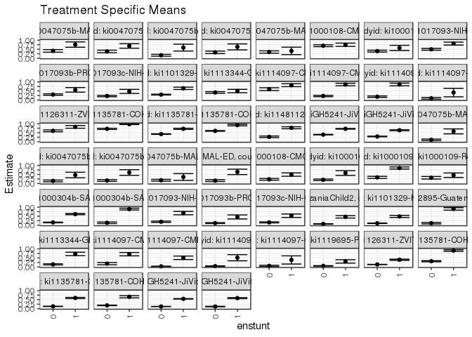

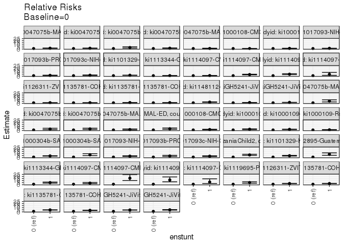

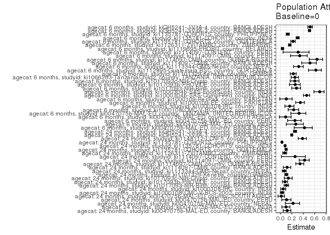

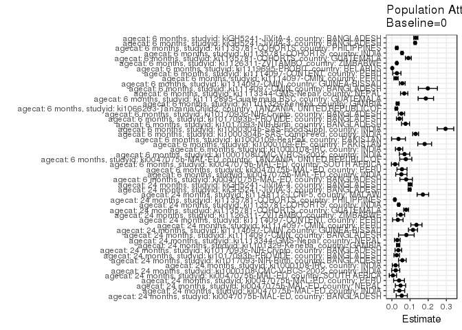

## Results Table

### Parameter: TSM

| agecat | studyid | country | intervention_level | baseline_level | estimate | ci_lower | ci_upper |
| --- | --- | --- | --- | --- | --- | --- | --- |
| 6 months | ki0047075b-MAL-ED | BANGLADESH | 0 | NA | 0.1081707 | 0.0655100 | 0.1508314 |
| 6 months | ki0047075b-MAL-ED | BANGLADESH | 1 | NA | 0.5733522 | 0.4365876 | 0.7101168 |
| 6 months | ki0047075b-MAL-ED | INDIA | 0 | NA | 0.1427201 | 0.0938333 | 0.1916069 |
| 6 months | ki0047075b-MAL-ED | INDIA | 1 | NA | 0.4711078 | 0.3189969 | 0.6232186 |
| 6 months | ki0047075b-MAL-ED | PERU | 0 | NA | 0.1640417 | 0.1170809 | 0.2110026 |
| 6 months | ki0047075b-MAL-ED | PERU | 1 | NA | 0.6067444 | 0.4499078 | 0.7635810 |
| 6 months | ki0047075b-MAL-ED | SOUTH AFRICA | 0 | NA | 0.1790393 | 0.1292860 | 0.2287927 |
| 6 months | ki0047075b-MAL-ED | SOUTH AFRICA | 1 | NA | 0.3600000 | 0.1714720 | 0.5485280 |
| 6 months | ki0047075b-MAL-ED | TANZANIA, UNITED REPUBLIC OF | 0 | NA | 0.1581663 | 0.1084603 | 0.2078724 |
| 6 months | ki0047075b-MAL-ED | TANZANIA, UNITED REPUBLIC OF | 1 | NA | 0.6420672 | 0.4926667 | 0.7914676 |
| 6 months | ki1000108-CMC-V-BCS-2002 | INDIA | 0 | NA | 0.2309391 | 0.1833978 | 0.2784804 |
| 6 months | ki1000108-CMC-V-BCS-2002 | INDIA | 1 | NA | 0.4942665 | 0.4017881 | 0.5867450 |
| 6 months | ki1000108-IRC | INDIA | 0 | NA | 0.2059764 | 0.1642988 | 0.2476540 |
| 6 months | ki1000108-IRC | INDIA | 1 | NA | 0.5779122 | 0.4469638 | 0.7088605 |
| 6 months | ki1000109-EE | PAKISTAN | 0 | NA | 0.3382349 | 0.2795152 | 0.3969546 |
| 6 months | ki1000109-EE | PAKISTAN | 1 | NA | 0.8557277 | 0.7980591 | 0.9133963 |
| 6 months | ki1000109-ResPak | PAKISTAN | 0 | NA | 0.3167817 | 0.2473688 | 0.3861947 |
| 6 months | ki1000109-ResPak | PAKISTAN | 1 | NA | 0.4582639 | 0.3349102 | 0.5816176 |
| 6 months | ki1000304b-SAS-CompFeed | INDIA | 0 | NA | 0.1536884 | 0.1340680 | 0.1733088 |
| 6 months | ki1000304b-SAS-CompFeed | INDIA | 1 | NA | 0.6141542 | 0.5807425 | 0.6475659 |
| 6 months | ki1000304b-SAS-FoodSuppl | INDIA | 0 | NA | 0.1335190 | 0.0896727 | 0.1773652 |
| 6 months | ki1000304b-SAS-FoodSuppl | INDIA | 1 | NA | 0.8920890 | 0.8420935 | 0.9420845 |
| 6 months | ki1017093-NIH-Birth | BANGLADESH | 0 | NA | 0.1929690 | 0.1567493 | 0.2291888 |
| 6 months | ki1017093-NIH-Birth | BANGLADESH | 1 | NA | 0.6714296 | 0.5789141 | 0.7639450 |
| 6 months | ki1017093b-PROVIDE | BANGLADESH | 0 | NA | 0.1195790 | 0.0918077 | 0.1473503 |
| 6 months | ki1017093b-PROVIDE | BANGLADESH | 1 | NA | 0.4591129 | 0.3470262 | 0.5711995 |
| 6 months | ki1017093c-NIH-Crypto | BANGLADESH | 0 | NA | 0.1569835 | 0.1282326 | 0.1857344 |
| 6 months | ki1017093c-NIH-Crypto | BANGLADESH | 1 | NA | 0.5246228 | 0.4280271 | 0.6212185 |
| 6 months | ki1066203-TanzaniaChild2 | TANZANIA, UNITED REPUBLIC OF | 0 | NA | 0.0724084 | 0.0607683 | 0.0840485 |
| 6 months | ki1066203-TanzaniaChild2 | TANZANIA, UNITED REPUBLIC OF | 1 | NA | 0.4649813 | 0.3977925 | 0.5321700 |

[output cut: 74 more lines]

### Parameter: E(Y)

| agecat | studyid | country | intervention_level | baseline_level | estimate | ci_lower | ci_upper |
| --- | --- | --- | --- | --- | --- | --- | --- |
| 6 months | ki0047075b-MAL-ED | BANGLADESH | NA | NA | 0.1867220 | 0.1374205 | 0.2360234 |
| 6 months | ki0047075b-MAL-ED | INDIA | NA | NA | 0.1949153 | 0.1442678 | 0.2455627 |
| 6 months | ki0047075b-MAL-ED | PERU | NA | NA | 0.2197802 | 0.1705687 | 0.2689917 |
| 6 months | ki0047075b-MAL-ED | SOUTH AFRICA | NA | NA | 0.1968504 | 0.1478551 | 0.2458457 |
| 6 months | ki0047075b-MAL-ED | TANZANIA, UNITED REPUBLIC OF | NA | NA | 0.2348178 | 0.1818480 | 0.2877876 |
| 6 months | ki1000108-CMC-V-BCS-2002 | INDIA | NA | NA | 0.3008130 | 0.2539566 | 0.3476694 |
| 6 months | ki1000108-IRC | INDIA | NA | NA | 0.2457002 | 0.2038248 | 0.2875757 |
| 6 months | ki1000109-EE | PAKISTAN | NA | NA | 0.5188172 | 0.4679751 | 0.5696593 |
| 6 months | ki1000109-ResPak | PAKISTAN | NA | NA | 0.3531915 | 0.2919518 | 0.4144312 |
| 6 months | ki1000304b-SAS-CompFeed | INDIA | NA | NA | 0.2844311 | 0.2666491 | 0.3022132 |
| 6 months | ki1000304b-SAS-FoodSuppl | INDIA | NA | NA | 0.4289474 | 0.3791199 | 0.4787748 |
| 6 months | ki1017093-NIH-Birth | BANGLADESH | NA | NA | 0.2681564 | 0.2306532 | 0.3056597 |
| 6 months | ki1017093b-PROVIDE | BANGLADESH | NA | NA | 0.1612350 | 0.1313580 | 0.1911120 |
| 6 months | ki1017093c-NIH-Crypto | BANGLADESH | NA | NA | 0.2097902 | 0.1799252 | 0.2396552 |
| 6 months | ki1066203-TanzaniaChild2 | TANZANIA, UNITED REPUBLIC OF | NA | NA | 0.0970922 | 0.0842059 | 0.1099785 |
| 6 months | ki1101329-Keneba | GAMBIA | NA | NA | 0.1412159 | 0.1262788 | 0.1561530 |
| 6 months | ki1112895-Guatemala BSC | GUATEMALA | NA | NA | 0.3010033 | 0.2489243 | 0.3530824 |
| 6 months | ki1113344-GMS-Nepal | NEPAL | NA | NA | 0.2113677 | 0.1776128 | 0.2451225 |
| 6 months | ki1114097-CMIN | BANGLADESH | NA | NA | 0.3827160 | 0.3214780 | 0.4439541 |
| 6 months | ki1114097-CMIN | GUINEA-BISSAU | NA | NA | 0.0896226 | 0.0703861 | 0.1088591 |
| 6 months | ki1114097-CMIN | PERU | NA | NA | 0.0675039 | 0.0480051 | 0.0870027 |
| 6 months | ki1114097-CONTENT | PERU | NA | NA | 0.0883721 | 0.0503437 | 0.1264005 |
| 6 months | ki1119695-PROBIT | BELARUS | NA | NA | 0.0626864 | 0.0488489 | 0.0765239 |
| 6 months | ki1126311-ZVITAMBO | ZIMBABWE | NA | NA | 0.1662447 | 0.1582324 | 0.1742571 |
| 6 months | ki1135781-COHORTS | GUATEMALA | NA | NA | 0.4099896 | 0.3788775 | 0.4411017 |
| 6 months | ki1135781-COHORTS | INDIA | NA | NA | 0.1854227 | 0.1762253 | 0.1946201 |
| 6 months | ki1135781-COHORTS | PHILIPPINES | NA | NA | 0.2112260 | 0.1958496 | 0.2266024 |
| 6 months | kiGH5241-JiVitA-3 | BANGLADESH | NA | NA | 0.2514221 | 0.2433018 | 0.2595424 |
| 6 months | kiGH5241-JiVitA-4 | BANGLADESH | NA | NA | 0.2528565 | 0.2387323 | 0.2669808 |
| 24 months | ki0047075b-MAL-ED | BANGLADESH | NA | NA | 0.4622642 | 0.3949918 | 0.5295365 |
| 24 months | ki0047075b-MAL-ED | INDIA | NA | NA | 0.4185022 | 0.3541865 | 0.4828179 |
| 24 months | ki0047075b-MAL-ED | NEPAL | NA | NA | 0.2149123 | 0.1614774 | 0.2683472 |
| 24 months | ki0047075b-MAL-ED | PERU | NA | NA | 0.3681592 | 0.3013164 | 0.4350020 |
| 24 months | ki0047075b-MAL-ED | SOUTH AFRICA | NA | NA | 0.3529412 | 0.2921001 | 0.4137823 |
| 24 months | ki1000108-CMC-V-BCS-2002 | INDIA | NA | NA | 0.7150538 | 0.6691221 | 0.7609854 |
| 24 months | ki1000108-IRC | INDIA | NA | NA | 0.4156479 | 0.3678270 | 0.4634689 |
| 24 months | ki1017093-NIH-Birth | BANGLADESH | NA | NA | 0.5547786 | 0.5076945 | 0.6018626 |
| 24 months | ki1017093b-PROVIDE | BANGLADESH | NA | NA | 0.3292894 | 0.2909105 | 0.3676684 |
| 24 months | ki1017093c-NIH-Crypto | BANGLADESH | NA | NA | 0.2568093 | 0.2190047 | 0.2946140 |
| 24 months | ki1101329-Keneba | GAMBIA | NA | NA | 0.3344928 | 0.3122213 | 0.3567642 |
| 24 months | ki1113344-GMS-Nepal | NEPAL | NA | NA | 0.4468938 | 0.4032281 | 0.4905594 |
| 24 months | ki1114097-CMIN | BANGLADESH | NA | NA | 0.6818182 | 0.6230135 | 0.7406228 |
| 24 months | ki1114097-CMIN | GUINEA-BISSAU | NA | NA | 0.3393829 | 0.2998111 | 0.3789548 |
| 24 months | ki1114097-CMIN | PERU | NA | NA | 0.3193473 | 0.2751780 | 0.3635166 |
| 24 months | ki1114097-CONTENT | PERU | NA | NA | 0.1280488 | 0.0767522 | 0.1793453 |
| 24 months | ki1126311-ZVITAMBO | ZIMBABWE | NA | NA | 0.6520788 | 0.6083612 | 0.6957964 |
| 24 months | ki1135781-COHORTS | GUATEMALA | NA | NA | 0.7912395 | 0.7669103 | 0.8155688 |
| 24 months | ki1135781-COHORTS | INDIA | NA | NA | 0.4621723 | 0.4487989 | 0.4755457 |
| 24 months | ki1135781-COHORTS | PHILIPPINES | NA | NA | 0.6167689 | 0.5974942 | 0.6360437 |
| 24 months | ki1148112-LCNI-5 | MALAWI | NA | NA | 0.4421416 | 0.4016536 | 0.4826297 |
| 24 months | kiGH5241-JiVitA-3 | BANGLADESH | NA | NA | 0.4907117 | 0.4775909 | 0.5038326 |
| 24 months | kiGH5241-JiVitA-4 | BANGLADESH | NA | NA | 0.3930380 | 0.3758543 | 0.4102217 |

### Parameter: RR

| agecat | studyid | country | intervention_level | baseline_level | estimate | ci_lower | ci_upper |
| --- | --- | --- | --- | --- | --- | --- | --- |
| 6 months | ki0047075b-MAL-ED | BANGLADESH | 0 | 0 | 1.000000 | 1.0000000 | 1.000000 |
| 6 months | ki0047075b-MAL-ED | BANGLADESH | 1 | 0 | 5.300439 | 3.3437426 | 8.402158 |
| 6 months | ki0047075b-MAL-ED | INDIA | 0 | 0 | 1.000000 | 1.0000000 | 1.000000 |
| 6 months | ki0047075b-MAL-ED | INDIA | 1 | 0 | 3.300922 | 2.0610475 | 5.286673 |
| 6 months | ki0047075b-MAL-ED | PERU | 0 | 0 | 1.000000 | 1.0000000 | 1.000000 |
| 6 months | ki0047075b-MAL-ED | PERU | 1 | 0 | 3.698720 | 2.5143259 | 5.441032 |
| 6 months | ki0047075b-MAL-ED | SOUTH AFRICA | 0 | 0 | 1.000000 | 1.0000000 | 1.000000 |
| 6 months | ki0047075b-MAL-ED | SOUTH AFRICA | 1 | 0 | 2.010732 | 1.1114293 | 3.637696 |
| 6 months | ki0047075b-MAL-ED | TANZANIA, UNITED REPUBLIC OF | 0 | 0 | 1.000000 | 1.0000000 | 1.000000 |
| 6 months | ki0047075b-MAL-ED | TANZANIA, UNITED REPUBLIC OF | 1 | 0 | 4.059443 | 2.7475389 | 5.997758 |
| 6 months | ki1000108-CMC-V-BCS-2002 | INDIA | 0 | 0 | 1.000000 | 1.0000000 | 1.000000 |
| 6 months | ki1000108-CMC-V-BCS-2002 | INDIA | 1 | 0 | 2.140246 | 1.6206733 | 2.826389 |
| 6 months | ki1000108-IRC | INDIA | 0 | 0 | 1.000000 | 1.0000000 | 1.000000 |
| 6 months | ki1000108-IRC | INDIA | 1 | 0 | 2.805720 | 2.0711118 | 3.800888 |
| 6 months | ki1000109-EE | PAKISTAN | 0 | 0 | 1.000000 | 1.0000000 | 1.000000 |
| 6 months | ki1000109-EE | PAKISTAN | 1 | 0 | 2.529980 | 2.1011750 | 3.046296 |
| 6 months | ki1000109-ResPak | PAKISTAN | 0 | 0 | 1.000000 | 1.0000000 | 1.000000 |
| 6 months | ki1000109-ResPak | PAKISTAN | 1 | 0 | 1.446624 | 1.0230114 | 2.045646 |
| 6 months | ki1000304b-SAS-CompFeed | INDIA | 0 | 0 | 1.000000 | 1.0000000 | 1.000000 |
| 6 months | ki1000304b-SAS-CompFeed | INDIA | 1 | 0 | 3.996100 | 3.5391082 | 4.512101 |
| 6 months | ki1000304b-SAS-FoodSuppl | INDIA | 0 | 0 | 1.000000 | 1.0000000 | 1.000000 |
| 6 months | ki1000304b-SAS-FoodSuppl | INDIA | 1 | 0 | 6.681366 | 4.7889911 | 9.321515 |
| 6 months | ki1017093-NIH-Birth | BANGLADESH | 0 | 0 | 1.000000 | 1.0000000 | 1.000000 |
| 6 months | ki1017093-NIH-Birth | BANGLADESH | 1 | 0 | 3.479468 | 2.7611534 | 4.384652 |
| 6 months | ki1017093b-PROVIDE | BANGLADESH | 0 | 0 | 1.000000 | 1.0000000 | 1.000000 |
| 6 months | ki1017093b-PROVIDE | BANGLADESH | 1 | 0 | 3.839411 | 2.7406567 | 5.378665 |
| 6 months | ki1017093c-NIH-Crypto | BANGLADESH | 0 | 0 | 1.000000 | 1.0000000 | 1.000000 |
| 6 months | ki1017093c-NIH-Crypto | BANGLADESH | 1 | 0 | 3.341897 | 2.5790111 | 4.330450 |
| 6 months | ki1066203-TanzaniaChild2 | TANZANIA, UNITED REPUBLIC OF | 0 | 0 | 1.000000 | 1.0000000 | 1.000000 |
| 6 months | ki1066203-TanzaniaChild2 | TANZANIA, UNITED REPUBLIC OF | 1 | 0 | 6.421646 | 5.1768415 | 7.965771 |

[output cut: 74 more lines]

### Parameter: PAR

| agecat | studyid | country | intervention_level | baseline_level | estimate | ci_lower | ci_upper |
| --- | --- | --- | --- | --- | --- | --- | --- |
| 6 months | ki0047075b-MAL-ED | BANGLADESH | 0 | NA | 0.0785513 | 0.0441054 | 0.1129972 |
| 6 months | ki0047075b-MAL-ED | INDIA | 0 | NA | 0.0521952 | 0.0211321 | 0.0832582 |
| 6 months | ki0047075b-MAL-ED | PERU | 0 | NA | 0.0557385 | 0.0280518 | 0.0834251 |
| 6 months | ki0047075b-MAL-ED | SOUTH AFRICA | 0 | NA | 0.0178111 | -0.0024971 | 0.0381193 |
| 6 months | ki0047075b-MAL-ED | TANZANIA, UNITED REPUBLIC OF | 0 | NA | 0.0766515 | 0.0432954 | 0.1100075 |
| 6 months | ki1000108-CMC-V-BCS-2002 | INDIA | 0 | NA | 0.0698739 | 0.0413300 | 0.0984178 |
| 6 months | ki1000108-IRC | INDIA | 0 | NA | 0.0397238 | 0.0197010 | 0.0597466 |
| 6 months | ki1000109-EE | PAKISTAN | 0 | NA | 0.1805823 | 0.1424906 | 0.2186740 |
| 6 months | ki1000109-ResPak | PAKISTAN | 0 | NA | 0.0364097 | -0.0017614 | 0.0745809 |
| 6 months | ki1000304b-SAS-CompFeed | INDIA | 0 | NA | 0.1307427 | 0.1146609 | 0.1468246 |
| 6 months | ki1000304b-SAS-FoodSuppl | INDIA | 0 | NA | 0.2954284 | 0.2500910 | 0.3407658 |
| 6 months | ki1017093-NIH-Birth | BANGLADESH | 0 | NA | 0.0751874 | 0.0531820 | 0.0971928 |
| 6 months | ki1017093b-PROVIDE | BANGLADESH | 0 | NA | 0.0416560 | 0.0251057 | 0.0582062 |
| 6 months | ki1017093c-NIH-Crypto | BANGLADESH | 0 | NA | 0.0528067 | 0.0355765 | 0.0700370 |
| 6 months | ki1066203-TanzaniaChild2 | TANZANIA, UNITED REPUBLIC OF | 0 | NA | 0.0246837 | 0.0177799 | 0.0315876 |
| 6 months | ki1101329-Keneba | GAMBIA | 0 | NA | 0.0318614 | 0.0240047 | 0.0397181 |
| 6 months | ki1112895-Guatemala BSC | GUATEMALA | 0 | NA | 0.1869683 | 0.1443605 | 0.2295760 |
| 6 months | ki1113344-GMS-Nepal | NEPAL | 0 | NA | 0.0677993 | 0.0478656 | 0.0877330 |
| 6 months | ki1114097-CMIN | BANGLADESH | 0 | NA | 0.1981125 | 0.1456312 | 0.2505939 |
| 6 months | ki1114097-CMIN | GUINEA-BISSAU | 0 | NA | 0.0574633 | 0.0417346 | 0.0731921 |
| 6 months | ki1114097-CMIN | PERU | 0 | NA | 0.0228399 | 0.0111651 | 0.0345147 |
| 6 months | ki1114097-CONTENT | PERU | 0 | NA | 0.0274584 | 0.0048058 | 0.0501110 |
| 6 months | ki1119695-PROBIT | BELARUS | 0 | NA | 0.0022373 | 0.0010304 | 0.0034442 |
| 6 months | ki1126311-ZVITAMBO | ZIMBABWE | 0 | NA | 0.0271055 | 0.0232384 | 0.0309726 |
| 6 months | ki1135781-COHORTS | GUATEMALA | 0 | NA | 0.0906219 | 0.0745245 | 0.1067194 |
| 6 months | ki1135781-COHORTS | INDIA | 0 | NA | 0.0560383 | 0.0506106 | 0.0614659 |
| 6 months | ki1135781-COHORTS | PHILIPPINES | 0 | NA | 0.0270404 | 0.0210453 | 0.0330355 |
| 6 months | kiGH5241-JiVitA-3 | BANGLADESH | 0 | NA | 0.1282109 | 0.1225511 | 0.1338707 |
| 6 months | kiGH5241-JiVitA-4 | BANGLADESH | 0 | NA | 0.1318067 | 0.1204588 | 0.1431547 |
| 24 months | ki0047075b-MAL-ED | BANGLADESH | 0 | NA | 0.0544429 | 0.0237941 | 0.0850918 |
| 24 months | ki0047075b-MAL-ED | INDIA | 0 | NA | 0.0411116 | 0.0117080 | 0.0705153 |
| 24 months | ki0047075b-MAL-ED | NEPAL | 0 | NA | 0.0475092 | 0.0192042 | 0.0758141 |
| 24 months | ki0047075b-MAL-ED | PERU | 0 | NA | 0.0394226 | 0.0095742 | 0.0692711 |
| 24 months | ki0047075b-MAL-ED | SOUTH AFRICA | 0 | NA | 0.0057190 | -0.0143305 | 0.0257684 |
| 24 months | ki1000108-CMC-V-BCS-2002 | INDIA | 0 | NA | 0.0212058 | -0.0008771 | 0.0432887 |
| 24 months | ki1000108-IRC | INDIA | 0 | NA | 0.0205360 | 0.0024225 | 0.0386495 |
| 24 months | ki1017093-NIH-Birth | BANGLADESH | 0 | NA | 0.0577183 | 0.0365855 | 0.0788512 |
| 24 months | ki1017093b-PROVIDE | BANGLADESH | 0 | NA | 0.0264735 | 0.0114556 | 0.0414914 |
| 24 months | ki1017093c-NIH-Crypto | BANGLADESH | 0 | NA | 0.0356069 | 0.0173464 | 0.0538674 |
| 24 months | ki1101329-Keneba | GAMBIA | 0 | NA | 0.0345293 | 0.0255493 | 0.0435092 |
| 24 months | ki1113344-GMS-Nepal | NEPAL | 0 | NA | 0.0298568 | 0.0142319 | 0.0454817 |
| 24 months | ki1114097-CMIN | BANGLADESH | 0 | NA | 0.0798687 | 0.0369384 | 0.1227990 |
| 24 months | ki1114097-CMIN | GUINEA-BISSAU | 0 | NA | 0.1163639 | 0.0914054 | 0.1413224 |
| 24 months | ki1114097-CMIN | PERU | 0 | NA | 0.1353002 | 0.1046305 | 0.1659700 |
| 24 months | ki1114097-CONTENT | PERU | 0 | NA | 0.0328107 | 0.0039066 | 0.0617148 |
| 24 months | ki1126311-ZVITAMBO | ZIMBABWE | 0 | NA | 0.0486444 | 0.0270154 | 0.0702734 |
| 24 months | ki1135781-COHORTS | GUATEMALA | 0 | NA | 0.0784627 | 0.0649764 | 0.0919490 |
| 24 months | ki1135781-COHORTS | INDIA | 0 | NA | 0.0375503 | 0.0325417 | 0.0425590 |
| 24 months | ki1135781-COHORTS | PHILIPPINES | 0 | NA | 0.0163809 | 0.0123019 | 0.0204598 |
| 24 months | ki1148112-LCNI-5 | MALAWI | 0 | NA | 0.1708075 | 0.1390375 | 0.2025776 |
| 24 months | kiGH5241-JiVitA-3 | BANGLADESH | 0 | NA | 0.0973830 | 0.0895827 | 0.1051833 |
| 24 months | kiGH5241-JiVitA-4 | BANGLADESH | 0 | NA | 0.1007302 | 0.0899179 | 0.1115426 |

### Parameter: PAF

| agecat | studyid | country | intervention_level | baseline_level | estimate | ci_lower | ci_upper |
| --- | --- | --- | --- | --- | --- | --- | --- |
| 6 months | ki0047075b-MAL-ED | BANGLADESH | 0 | NA | 0.4206858 | 0.2402049 | 0.5582955 |
| 6 months | ki0047075b-MAL-ED | INDIA | 0 | NA | 0.2677840 | 0.1025323 | 0.4026077 |
| 6 months | ki0047075b-MAL-ED | PERU | 0 | NA | 0.2536101 | 0.1257257 | 0.3627882 |
| 6 months | ki0047075b-MAL-ED | SOUTH AFRICA | 0 | NA | 0.0904803 | -0.0172293 | 0.1867851 |
| 6 months | ki0047075b-MAL-ED | TANZANIA, UNITED REPUBLIC OF | 0 | NA | 0.3264295 | 0.1824318 | 0.4450651 |
| 6 months | ki1000108-CMC-V-BCS-2002 | INDIA | 0 | NA | 0.2322835 | 0.1350132 | 0.3186155 |
| 6 months | ki1000108-IRC | INDIA | 0 | NA | 0.1616760 | 0.0785466 | 0.2373058 |
| 6 months | ki1000109-EE | PAKISTAN | 0 | NA | 0.3480654 | 0.2673269 | 0.4199067 |
| 6 months | ki1000109-ResPak | PAKISTAN | 0 | NA | 0.1030878 | -0.0117569 | 0.2048965 |
| 6 months | ki1000304b-SAS-CompFeed | INDIA | 0 | NA | 0.4596639 | 0.4025888 | 0.5112862 |
| 6 months | ki1000304b-SAS-FoodSuppl | INDIA | 0 | NA | 0.6887288 | 0.5867527 | 0.7655405 |
| 6 months | ki1017093-NIH-Birth | BANGLADESH | 0 | NA | 0.2803863 | 0.1984982 | 0.3539081 |
| 6 months | ki1017093b-PROVIDE | BANGLADESH | 0 | NA | 0.2583558 | 0.1577547 | 0.3469407 |
| 6 months | ki1017093c-NIH-Crypto | BANGLADESH | 0 | NA | 0.2517120 | 0.1704018 | 0.3250528 |
| 6 months | ki1066203-TanzaniaChild2 | TANZANIA, UNITED REPUBLIC OF | 0 | NA | 0.2542299 | 0.1874979 | 0.3154812 |
| 6 months | ki1101329-Keneba | GAMBIA | 0 | NA | 0.2256218 | 0.1722183 | 0.2755800 |
| 6 months | ki1112895-Guatemala BSC | GUATEMALA | 0 | NA | 0.6211501 | 0.4925719 | 0.7171476 |
| 6 months | ki1113344-GMS-Nepal | NEPAL | 0 | NA | 0.3207648 | 0.2303163 | 0.4005843 |
| 6 months | ki1114097-CMIN | BANGLADESH | 0 | NA | 0.5176489 | 0.3725395 | 0.6291996 |
| 6 months | ki1114097-CMIN | GUINEA-BISSAU | 0 | NA | 0.6411699 | 0.5055956 | 0.7395673 |
| 6 months | ki1114097-CMIN | PERU | 0 | NA | 0.3383489 | 0.1751604 | 0.4692517 |
| 6 months | ki1114097-CONTENT | PERU | 0 | NA | 0.3107133 | 0.0459028 | 0.5020255 |
| 6 months | ki1119695-PROBIT | BELARUS | 0 | NA | 0.0356906 | 0.0151602 | 0.0557930 |
| 6 months | ki1126311-ZVITAMBO | ZIMBABWE | 0 | NA | 0.1630458 | 0.1403965 | 0.1850983 |
| 6 months | ki1135781-COHORTS | GUATEMALA | 0 | NA | 0.2210347 | 0.1804754 | 0.2595867 |
| 6 months | ki1135781-COHORTS | INDIA | 0 | NA | 0.3022189 | 0.2751855 | 0.3282440 |
| 6 months | ki1135781-COHORTS | PHILIPPINES | 0 | NA | 0.1280164 | 0.1000451 | 0.1551184 |
| 6 months | kiGH5241-JiVitA-3 | BANGLADESH | 0 | NA | 0.5099428 | 0.4904889 | 0.5286540 |
| 6 months | kiGH5241-JiVitA-4 | BANGLADESH | 0 | NA | 0.5212708 | 0.4794774 | 0.5597086 |
| 24 months | ki0047075b-MAL-ED | BANGLADESH | 0 | NA | 0.1177745 | 0.0476933 | 0.1826983 |
| 24 months | ki0047075b-MAL-ED | INDIA | 0 | NA | 0.0982352 | 0.0247126 | 0.1662152 |
| 24 months | ki0047075b-MAL-ED | NEPAL | 0 | NA | 0.2210630 | 0.0853437 | 0.3366439 |
| 24 months | ki0047075b-MAL-ED | PERU | 0 | NA | 0.1070804 | 0.0222677 | 0.1845361 |
| 24 months | ki0047075b-MAL-ED | SOUTH AFRICA | 0 | NA | 0.0162037 | -0.0422806 | 0.0714063 |
| 24 months | ki1000108-CMC-V-BCS-2002 | INDIA | 0 | NA | 0.0296562 | -0.0019141 | 0.0602318 |
| 24 months | ki1000108-IRC | INDIA | 0 | NA | 0.0494072 | 0.0046760 | 0.0921282 |
| 24 months | ki1017093-NIH-Birth | BANGLADESH | 0 | NA | 0.1040385 | 0.0639295 | 0.1424290 |
| 24 months | ki1017093b-PROVIDE | BANGLADESH | 0 | NA | 0.0803959 | 0.0337400 | 0.1247989 |
| 24 months | ki1017093c-NIH-Crypto | BANGLADESH | 0 | NA | 0.1386511 | 0.0659694 | 0.2056772 |
| 24 months | ki1101329-Keneba | GAMBIA | 0 | NA | 0.1032287 | 0.0760923 | 0.1295681 |
| 24 months | ki1113344-GMS-Nepal | NEPAL | 0 | NA | 0.0668096 | 0.0309827 | 0.1013120 |
| 24 months | ki1114097-CMIN | BANGLADESH | 0 | NA | 0.1171408 | 0.0494761 | 0.1799885 |
| 24 months | ki1114097-CMIN | GUINEA-BISSAU | 0 | NA | 0.3428690 | 0.2690297 | 0.4092495 |
| 24 months | ki1114097-CMIN | PERU | 0 | NA | 0.4236773 | 0.3292565 | 0.5048065 |
| 24 months | ki1114097-CONTENT | PERU | 0 | NA | 0.2562358 | 0.0179802 | 0.4366864 |
| 24 months | ki1126311-ZVITAMBO | ZIMBABWE | 0 | NA | 0.0745989 | 0.0398995 | 0.1080443 |
| 24 months | ki1135781-COHORTS | GUATEMALA | 0 | NA | 0.0991643 | 0.0804104 | 0.1175357 |
| 24 months | ki1135781-COHORTS | INDIA | 0 | NA | 0.0812474 | 0.0702172 | 0.0921469 |
| 24 months | ki1135781-COHORTS | PHILIPPINES | 0 | NA | 0.0265592 | 0.0198141 | 0.0332579 |
| 24 months | ki1148112-LCNI-5 | MALAWI | 0 | NA | 0.3863186 | 0.3112964 | 0.4531685 |
| 24 months | kiGH5241-JiVitA-3 | BANGLADESH | 0 | NA | 0.1984526 | 0.1815765 | 0.2149808 |
| 24 months | kiGH5241-JiVitA-4 | BANGLADESH | 0 | NA | 0.2562862 | 0.2281386 | 0.2834073 |